# homework-1

Lizhiyuan

2022-06-28

# 1. The Iowa data set iowa.csv is a toy example that summarises the yield of wheat (bushels per acre) forthe state of Iowa between 1930-1962. In addition to yield, year, rainfall and temperature were recordedas the main predictors of yield.

## a. First, we need to load the data set into R using the command read.csv(). Use the help functionto learn what arguments this function takes. Once you have the necessary input, load the dataset into R and make it a data frame called iowa.df.

```r
library(ggplot2)
iow.df = read.csv( "C:\\Users\\86176\\Documents\\github\\my-repo\\data\\iowa.csv",sep = ";")
iow.df
```

| Year | Rain0 | Temp1 | Rain1 | Temp2 | Rain2 | Temp3 | Rain3 | Temp4 | Yield |
| --- | --- | --- | --- | --- | --- | --- | --- | --- | --- |
| 1930 | 17.75 | 60.2 | 5.83 | 69.0 | 1.49 | 77.9 | 2.42 | 74.4 | 34.0 |
| 1931 | 14.76 | 57.5 | 3.83 | 75.0 | 2.72 | 77.2 | 3.30 | 72.6 | 32.9 |
| 1932 | 27.99 | 62.3 | 5.17 | 72.0 | 3.12 | 75.8 | 7.10 | 72.2 | 43.0 |
| 1933 | 16.76 | 60.5 | 1.64 | 77.8 | 3.45 | 76.4 | 3.01 | 70.5 | 40.0 |
| 1934 | 11.36 | 69.5 | 3.49 | 77.2 | 3.85 | 79.7 | 2.84 | 73.4 | 23.0 |
| 1935 | 22.71 | 55.0 | 7.00 | 65.9 | 3.35 | 79.4 | 2.42 | 73.6 | 38.4 |
| 1936 | 17.91 | 66.2 | 2.85 | 70.1 | 0.51 | 83.4 | 3.48 | 79.2 | 20.0 |
| 1937 | 23.31 | 61.8 | 3.80 | 69.0 | 2.63 | 75.9 | 3.99 | 77.8 | 44.6 |
| 1938 | 18.53 | 59.5 | 4.67 | 69.2 | 4.24 | 76.5 | 3.82 | 75.7 | 46.3 |
| 1939 | 18.56 | 66.4 | 5.32 | 71.4 | 3.15 | 76.2 | 4.72 | 70.7 | 52.2 |

[output cut: 23 more lines]

## b. How many rows and columns does iowa.df have?

```r
dim(iow.df)
```

```
## [1] 33 10
```

### 33行，10列

## c. What are the names of the columns of iowa.df?

### 列名分别为Year.Rain0.Temp1.Rain1.Temp2.Rain2.Temp3.Rain3.Temp4.Yield

## d.What is the value of row 5, column 7 of iowa.df?

```r
iow.df[5, 7]
```

```
## [1] 79.7
```

### 数值为79.7

## e. Display the second row of iowa.df in its entirety

```r
iow.df[2,]
```

|  | Year | Rain0 | Temp1 | Rain1 | Temp2 | Rain2 | Temp3 | Rain3 | Temp4 | Yield |
| --- | --- | --- | --- | --- | --- | --- | --- | --- | --- | --- |
| 2 | 1931 | 14.76 | 57.5 | 3.83 | 75 | 2.72 | 77.2 | 3.3 | 72.6 | 32.9 |

# 2. Syntax and class-typing

## a. For each of the following commands, either explain why they should be errors, or explain thenon-erroneous result

```r
vector1 <- c("5", "12", "7", "32")
max(vector1)
```

```
## [1] "7"
```

```r
sort(vector1)
```

```
## [1] "12" "32" "5"  "7"
```

```r
#sum(vector1)
```

### 由于向量内的值均为字符串，以每个字符串第一个值来判断大小排序，故vector1中最大值为7，排序默认从小到大故结果为此，而sum报错的原因是无法对字符串数据类型求和。

## b. For the next series of commands, either explain their results, or why they should produce errors.

```r
vector2 <- c("5",7,12)
#vector2[2] + vector2[3]
dataframe3 <- data.frame(z1="5",z2=7,z3=12)
dataframe3[1,2] + dataframe3[1,3]
```

```
## [1] 19
```

```r
list4 <- list(z1="6", z2=42, z3="49", z4=126)
list4[[2]]+list4[[4]]
```

```
## [1] 168
```

```r
#list[2]+list4[4]
```

### 出现错误的的代码被注释掉，第一个错误出现的原因是，vector数据储存统一数据类型，即内部数据全部为字符串，第二个错误出现的原因为list[2]为42对应的键值。

# 3. Working with functions and operators

## a. The colon operator will create a sequence of integers in order. It is a special case of the functionseq() which you saw earlier in this assignment. Using the help command ?seq to learn aboutthe function, design an expression that will give you the sequence of numbers from 1 to 10000in increments of 372. Design another that will give you a sequence between 1 and 10000 that isexactly 50 numbers in length.

```r
seq(from = 1, to = 10000, by = 372)
```

```
##  [1]    1  373  745 1117 1489 1861 2233 2605 2977 3349 3721 4093 4465 4837 5209
## [16] 5581 5953 6325 6697 7069 7441 7813 8185 8557 8929 9301 9673
```

```r
seq(from = 1, to = 10000, length.out = 50)
```

```
##  [1]     1.0000   205.0612   409.1224   613.1837   817.2449  1021.3061
##  [7]  1225.3673  1429.4286  1633.4898  1837.5510  2041.6122  2245.6735
## [13]  2449.7347  2653.7959  2857.8571  3061.9184  3265.9796  3470.0408
## [19]  3674.1020  3878.1633  4082.2245  4286.2857  4490.3469  4694.4082
## [25]  4898.4694  5102.5306  5306.5918  5510.6531  5714.7143  5918.7755
## [31]  6122.8367  6326.8980  6530.9592  6735.0204  6939.0816  7143.1429
## [37]  7347.2041  7551.2653  7755.3265  7959.3878  8163.4490  8367.5102
## [43]  8571.5714  8775.6327  8979.6939  9183.7551  9387.8163  9591.8776
## [49]  9795.9388 10000.0000
```

##b. The function rep() repeats a vector some number of times. Explain the difference betweenrep(1:3, times=3) and rep(1:3, each=3).

```r
rep(1:3, times=3)
```

```
## [1] 1 2 3 1 2 3 1 2 3
```

```r
rep(1:3, each=3)
```

```
## [1] 1 1 1 2 2 2 3 3 3
```

### times参数指向量循环几次，each指每个值重复几次

# MB.Ch1.2. The orings data frame gives data on the damage that had occurred in US space shuttle launchesprior to the disastrous Challenger launch of 28 January 1986. The observations in rows 1, 2, 4, 11, 13, and 18were included in the pre-launch charts used in deciding whether to proceed with the launch, while remainingrows were omitted.Create a new data frame by extracting these rows from orings, and plot total incidents against temperaturefor this new data frame. Obtain a similar plot for the full data set.

```r
oring <-DAAG::orings
oring_new <- oring[c(1,2,4,11,13,18),]
oring_new
```

|  | Temperature | Erosion | Blowby | Total |
| --- | --- | --- | --- | --- |
| 1 | 53 | 3 | 2 | 5 |
| 2 | 57 | 1 | 0 | 1 |
| 4 | 63 | 1 | 0 | 1 |
| 11 | 70 | 1 | 0 | 1 |
| 13 | 70 | 1 | 0 | 1 |
| 18 | 75 | 0 | 2 | 1 |

```r
oring
```

|  | Temperature | Erosion | Blowby | Total |
| --- | --- | --- | --- | --- |
| 1 | 53 | 3 | 2 | 5 |
| 2 | 57 | 1 | 0 | 1 |
| 3 | 58 | 1 | 0 | 1 |
| 4 | 63 | 1 | 0 | 1 |
| 5 | 66 | 0 | 0 | 0 |
| 6 | 67 | 0 | 0 | 0 |
| 7 | 67 | 0 | 0 | 0 |
| 8 | 67 | 0 | 0 | 0 |
| 9 | 68 | 0 | 0 | 0 |
| 10 | 69 | 0 | 0 | 0 |

[output cut: 13 more lines]

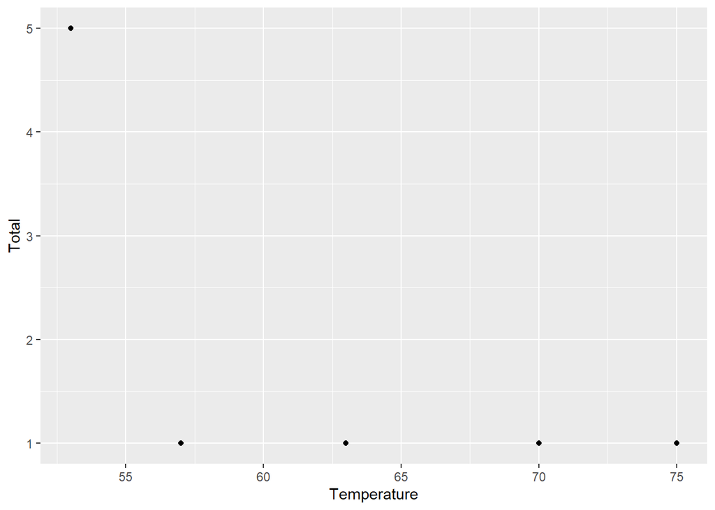

```r
ggplot(data = oring_new) +
  geom_point(aes(x = Temperature, y = Total))
```

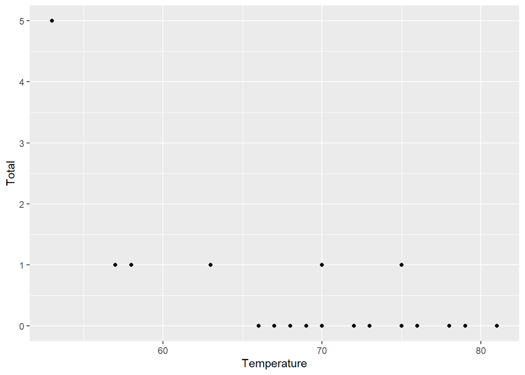

```r
ggplot(data = oring) +
  geom_point(aes(x = Temperature, y = Total))
```

# MB.Ch1.4. For the data frame ais (DAAG package)

## (a) Use the function str() to get information on each of the columns. Determine whether any of thecolumns hold missing values

```r
ais.df <- DAAG::ais
str(ais.df)
```

```
## 'data.frame':    202 obs. of  13 variables:
##  $ rcc   : num  3.96 4.41 4.14 4.11 4.45 4.1 4.31 4.42 4.3 4.51 ...
##  $ wcc   : num  7.5 8.3 5 5.3 6.8 4.4 5.3 5.7 8.9 4.4 ...
##  $ hc    : num  37.5 38.2 36.4 37.3 41.5 37.4 39.6 39.9 41.1 41.6 ...
##  $ hg    : num  12.3 12.7 11.6 12.6 14 12.5 12.8 13.2 13.5 12.7 ...
##  $ ferr  : num  60 68 21 69 29 42 73 44 41 44 ...
##  $ bmi   : num  20.6 20.7 21.9 21.9 19 ...
##  $ ssf   : num  109.1 102.8 104.6 126.4 80.3 ...
##  $ pcBfat: num  19.8 21.3 19.9 23.7 17.6 ...
##  $ lbm   : num  63.3 58.5 55.4 57.2 53.2 ...
##  $ ht    : num  196 190 178 185 185 ...
##  $ wt    : num  78.9 74.4 69.1 74.9 64.6 63.7 75.2 62.3 66.5 62.9 ...
##  $ sex   : Factor w/ 2 levels "f","m": 1 1 1 1 1 1 1 1 1 1 ...
##  $ sport : Factor w/ 10 levels "B_Ball","Field",..: 1 1 1 1 1 1 1 1 1 1 ...
```

```r
any(is.na(ais.df[,1]))
```

```
## [1] FALSE
```

```r
any(is.na(ais.df[,2]))
```

```
## [1] FALSE
```

```r
any(is.na(ais.df[,3]))
```

```
## [1] FALSE
```

```r
any(is.na(ais.df[,4]))
```

```
## [1] FALSE
```

```r
any(is.na(ais.df[,5]))
```

```
## [1] FALSE
```

```r
any(is.na(ais.df[,6]))
```

```
## [1] FALSE
```

```r
any(is.na(ais.df[,7]))
```

```
## [1] FALSE
```

```r
any(is.na(ais.df[,8]))
```

```
## [1] FALSE
```

```r
any(is.na(ais.df[,9]))
```

```
## [1] FALSE
```

```r
any(is.na(ais.df[,10]))
```

```
## [1] FALSE
```

```r
any(is.na(ais.df[,11]))
```

```
## [1] FALSE
```

```r
any(is.na(ais.df[,12]))
```

```
## [1] FALSE
```

```r
any(is.na(ais.df[,13]))
```

```
## [1] FALSE
```

## (b) Make a table that shows the numbers of males and females for each different sport. In which sports isthere a large imbalance (e.g., by a factor of more than 2:1) in the numbers of the two sexes?

```r
female_sports_table <- table(ais.df[ais.df[,12] == 'f',13])
male_sports_table <- table(ais.df[ais.df[,12]=='m',13])
female_sports_table
```

```
##
##  B_Ball   Field     Gym Netball     Row    Swim  T_400m T_Sprnt  Tennis  W_Polo
##      13       7       4      23      22       9      11       4       7       0
```

```r
male_sports_table
```

```
##
##  B_Ball   Field     Gym Netball     Row    Swim  T_400m T_Sprnt  Tennis  W_Polo
##      12      12       0       0      15      13      18      11       4      17
```

```r
female_sports_table/male_sports_table
```

```
##
##    B_Ball     Field       Gym   Netball       Row      Swim    T_400m   T_Sprnt
## 1.0833333 0.5833333       Inf       Inf 1.4666667 0.6923077 0.6111111 0.3636364
##    Tennis    W_Polo
## 1.7500000 0.0000000
```

## 可以看到女生/男生，数值差较大的有Gym，Netball，T_Sprnt，W——Polo

# MB.Ch1.6.Create a data frame called Manitoba.lakes that contains the lake’s elevation (in meters above sealevel) and area (in square kilometers) as listed below. Assign the names of the lakes using the row.names()function